# Model selection

2025-04-19

Fit vital rate models used inside the simulation.

## Setup workspace

### Load packages

```r
library(dplyr)
```

```r
library(ggplot2)
library(hyenaR)
```

### Define parallel processing variables

```r
cores_used <- 8
```

### Define years where we will calculate K

```r
## Set a starting year. Filter out everything before this
start_yr <- 1997 # We ignore 1996 because majority are left censored individuals
end_yr   <- 2023 # We also have data from early 2024, but not enough samples for year RE
```

## Extract model data

```r
#Generate data to start simulation (at first observation)
if (file.exists(here::here("./data/model_data.RDS"))) {
  model_data <- readRDS(here::here("./data/model_data.RDS"))
} else {

  ## This was extract in April 2025, last sighting was Feb 2025.
  db.path <- here::here("./hyena_data/Fisidata_2025_04_18.sqlite")

  model_data <- SHIM::generate_model_data(db = db.path)

  saveRDS(model_data, here::here("./data/model_data.RDS"))

}
```

## Create utility fn

### Fit models w/ exponent

Refit a model with different exponent for clan size.

```r
fit_exp <- function(x, model, train_data, verbose = FALSE){

  train_data$old_clan_size <- train_data$clan_size
  train_data$clan_size     <- train_data$clan_size^x

  if (verbose) {
    mod <- update(model, data = train_data, family = family(model))
  } else {
    mod <- suppressMessages(update(model, data = train_data, family = family(model)))
  }
  return(mod)
}
```

### Calculate predictive accuracy

Calculate all values for a model

```r
est_accuracy <- function(model, test_data, name = "", verbose = TRUE, ...){

  ## Predict outcomes...
  predict <- as.numeric(spaMM::predict.HLfit(object = model, newdata = test_data))
  ## Convert observed outcomes (TRUE/FALSE) to integer
  event <- as.numeric(test_data$event)

  tibble(name = name,
         # mod = list(model), ## Don't save model because it breaks code to view
         ## Using prebuild fn DescTools::BrierScore & Metrics::logLoss
         ## Could also do manually
         logLik = logLik(model)[[1]],
         logLoss = Metrics::logLoss(event, predict),
         Brier = DescTools::BrierScore(x = event, pred = predict),
         ...)
}
```

### Refit with new exponent and add predictive accuracy

Refit and assess a model based with different exponent for clan size.

```r
fit_and_est <- function(exp, model, train_data, test_data, verbose = TRUE, pb = NULL){

  if (!is.null(pb)){
    pb$tick()
  }

  refit_model <- fit_exp(x = exp, model = model, train_data = train_data, verbose = verbose)

  est_accuracy(refit_model, test_data, name = paste("Exp:", exp), verbose = verbose, exponent = exp)

}
```

### Refit for MULTIPLE exponents and plot different accuracy metrics

Refit for multiple exponents and estimate fit.

```r
exp_profiling <- function(exp, model, train_data, test_data){

  pb <- progress::progress_bar$new(total = length(exp))
  manual_loglik_opt <- lapply(exp, FUN = fit_and_est, train_data = train_data, test_data = test_data, model = model, verbose = FALSE, pb = pb)

  ## Create plot w/ different metrics
  all_data <- manual_loglik_opt |>
    dplyr::bind_rows()

  ## Calculate p-value difference w/ 1 for logLik
  pval <- pchisq(-2 * (all_data$logLik[all_data$exponent == 1] - all_data$logLik[all_data$logLik == max(all_data$logLik)]), df = 1, lower.tail = FALSE)

  plot_data <- all_data |>
    tidyr::pivot_longer(cols = logLik:Brier, names_to = "metric")

  output_plot <- ggplot(data = plot_data) +
    geom_hline(data = data.frame(y = all_data$logLik[all_data$logLik == max(all_data$logLik)] - qchisq(p = 0.95, df = 1)/2,
                                 metric = "logLik"),
               aes(yintercept = y),
               lty = 2) +
    geom_text(data = data.frame(y = max(all_data$logLik),
                                metric = "logLik",
                                label = paste0("pval: ", round(pval, 2))),
              aes(y = y, x = mean(exp), label = label)) +
    geom_line(aes(x = exponent, y = value)) +
    geom_point(aes(x = exponent, y = value)) +
    scale_x_continuous(limits = range(exp)) +
    theme_bw() +
    facet_wrap(facets = ~metric, scales = "free_y")

  return(list(plot = output_plot,
              data = all_data))

}
```

### Custom atan fn

Adjust arctan function that can be used to scale month effects for reproduction. **NOTE:** This is currently not used in the script, but could be valuable to fit more bespoke reproduction functions to model IBI and age at first reproduction (which appear to be too occurring to rapidly in our simulation).

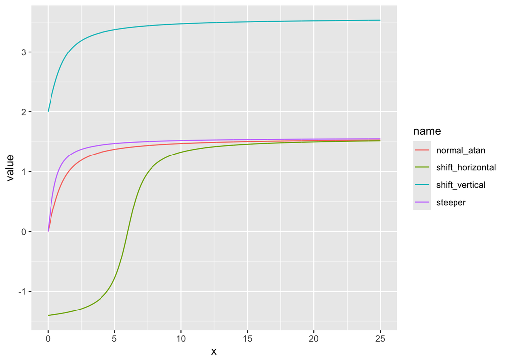

```r
## x: Variable to transform
## x0: Shift horizontal (so that INCREASE in repro starts at a later stage)
## a: Steepness of effect
## b: Shift vertical (so that absolute repro chance is higher)
custom_atan <- function(x, x0 = 0, a = 1, b = 0){
    atan(a*(x - x0)) + b
}

plot_data <- data.frame(x = seq(0, 25, 0.01)) |>
  mutate(normal_atan = custom_atan(x),
         shift_horizontal = custom_atan(x, x0 = 6),
         steeper = custom_atan(x, a = 2),
         shift_vertical = custom_atan(x, b = 2)
         ) |>
  tidyr::pivot_longer(cols = normal_atan:shift_vertical)

ggplot() +
  geom_line(data = plot_data,
            aes(x = x, y = value, colour = name))
```

## Fit models

### Female survival

```r
set.seed(10)
whole_data_Fsurv <- model_data$F_surv_data |>
  ## Make sure that 2024 is excluded (not enough data to estimate RE)
  dplyr::filter(year <= end_yr) |>
  ## Add rank category (top, middle, bottom)
  dplyr::mutate(rank_category2 = case_when(nat_rank_std >= 1/3 ~ "top",
                                           nat_rank_std < -1/3 ~ "bottom",
                                           TRUE ~ "middle")) |>
  dplyr::select(surv, year, rank_category2, age, clan_size, start_clan)

test_sample <- sample(1:nrow(whole_data_Fsurv), size = as.integer(nrow(whole_data_Fsurv)*0.05), replace = FALSE)

train_data_Fsurv <- whole_data_Fsurv[-test_sample, ]
test_data_Fsurv <- whole_data_Fsurv[test_sample, ] |>
  rename(event = surv)
```

For female survival, we want to test some different polynomes for age to better predict sensence.

```r
null_mod <- spaMM::fitme(surv ~ 1 + (1|start_clan:year),
                         data = train_data_Fsurv,
                         method = "PQL/L", family = binomial(link = "logit"))
F_surv_mod_logit_poly1 <- spaMM::fitme(surv ~ poly(age, 1)*rank_category2 +
                                         clan_size +
                                         ## Based on reviewer comments we may also want to add ID but
                                         ## this takes ages to converge on my Mac (need on server I guess)
                                         ## leaving out for now
                                         clan_size:rank_category2 + start_clan + (1|start_clan:year),
                                       data = train_data_Fsurv,
                                       method = "PQL/L", family = binomial(link = "logit"))

F_surv_mod_logit_poly2 <- spaMM::fitme(surv ~ poly(age, 2)*rank_category2 +
                                         clan_size +
                                         clan_size:rank_category2 + start_clan + (1|start_clan:year),
                                       data = train_data_Fsurv,
                                       method = "PQL/L", family = binomial(link = "logit"))
```

```
## Increase spaMM.options(separation_max=<.>) to at least 12 if you want to check separation (see 'help(separation)').
```

```r
F_surv_mod_logit_poly3 <- spaMM::fitme(surv ~ poly(age, 3)*rank_category2 +
                                         clan_size +
                                         clan_size:rank_category2 + start_clan + (1|start_clan:year),
                                       data = train_data_Fsurv,
                                       method = "PQL/L", family = binomial(link = "logit"))
```

```
## Increase spaMM.options(separation_max=<.>) to at least 14 if you want to check separation (see 'help(separation)').
```

```r
F_surv_mod_logit_poly4 <- spaMM::fitme(surv ~ poly(age, 4)*rank_category2 +
                                         clan_size +
                                         clan_size:rank_category2 + start_clan + (1|start_clan:year),
                                       data = train_data_Fsurv,
                                       method = "PQL/L", family = binomial(link = "logit"))
```

```
## Increase spaMM.options(separation_max=<.>) to at least 16 if you want to check separation (see 'help(separation)').
```

Compare polynomes and null model based on predictive accuracy.

```r
polynome_mods_Fsurv <- list(null_mod, F_surv_mod_logit_poly1,
                            F_surv_mod_logit_poly2, F_surv_mod_logit_poly3, F_surv_mod_logit_poly4)
polynome_accuracy_Fsurv <- purrr::map2_dfr(.x = polynome_mods_Fsurv,
                                           .y = c("null", "poly1", "poly2", "poly3", "poly4"),
                                           .f = function(mod, test_data, name){
                                             est_accuracy(model = mod, test_data = test_data, name = name)
                                           },
                                           test_data = test_data_Fsurv)
polynome_accuracy_Fsurv |>
  arrange(Brier)
```

```
## # A tibble: 5 × 4
##   name  logLik logLoss  Brier
##   <chr>  <dbl>   <dbl>  <dbl>
## 1 poly2 -4761.  0.0871 0.0181
## 2 poly4 -4744.  0.0876 0.0182
## 3 poly3 -4752.  0.0878 0.0183
## 4 poly1 -4838.  0.0911 0.0184
## 5 null  -4939.  0.0908 0.0185
```

Poly2 has slightly lower Brier score.

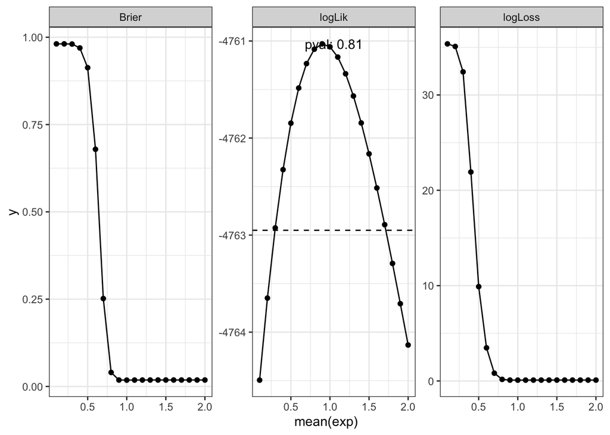

```r
best_fit_Fsurv <- exp_profiling(exp = seq(0.1, 2, 0.1), F_surv_mod_logit_poly2,
                                train_data = train_data_Fsurv, test_data = test_data_Fsurv)
best_fit_Fsurv$plot
```

```r
dplyr::bind_rows(polynome_accuracy_Fsurv, best_fit_Fsurv$data) |>
  dplyr::arrange(Brier)
```

```
## # A tibble: 25 × 5
##    name     logLik logLoss  Brier exponent
##    <chr>     <dbl>   <dbl>  <dbl>    <dbl>
##  1 poly2    -4761.  0.0871 0.0181     NA
##  2 Exp: 1   -4761.  0.0871 0.0181      1
##  3 poly4    -4744.  0.0876 0.0182     NA
##  4 poly3    -4752.  0.0878 0.0183     NA
##  5 Exp: 1.1 -4761.  0.0894 0.0183      1.1
##  6 Exp: 1.2 -4761.  0.0913 0.0184      1.2
##  7 poly1    -4838.  0.0911 0.0184     NA
##  8 Exp: 0.9 -4761.  0.0910 0.0184      0.9
##  9 Exp: 2   -4764.  0.0918 0.0184      2
## 10 Exp: 1.9 -4764.  0.0921 0.0184      1.9
## # ℹ 15 more rows
```

```
## Increase spaMM.options(separation_max=<.>) to at least 12 if you want to check separation (see 'help(separation)').
```

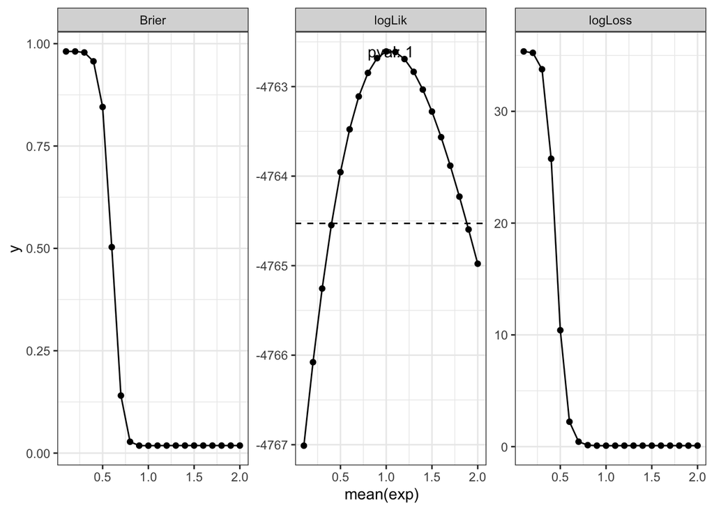

```r
output_table <- best_fit_Fsurv$data |>
  mutate(link = "logit",
         age_polynome = 2) |>
  bind_rows(polynome_accuracy_Fsurv |>
              filter(name != "poly2") |>
              mutate(link = "logit",
                     age_polynome = c(NA, 1, 3, 4),
                     exponent = c(NA, 1, 1, 1))) |>
  bind_rows(probit_fit_Fsurv$data |>
              mutate(link = "probit",
                     age_polynome = 2)) |>
  ## Arrange nicely
  select(link, exponent, age_polynome, Brier, logLoss, logLik) |>
  dplyr::arrange(Brier)
output_table
```

```
## # A tibble: 44 × 6
##    link   exponent age_polynome  Brier logLoss logLik
##    <chr>     <dbl>        <dbl>  <dbl>   <dbl>  <dbl>
##  1 logit       1              2 0.0181  0.0871 -4761.
##  2 probit      1              2 0.0181  0.0871 -4763.
##  3 logit       1              4 0.0182  0.0876 -4744.
##  4 logit       1              3 0.0183  0.0878 -4752.
##  5 logit       1.1            2 0.0183  0.0894 -4761.
##  6 probit      1.1            2 0.0183  0.0895 -4763.
##  7 probit      0.9            2 0.0183  0.0902 -4763.
##  8 logit       1.2            2 0.0184  0.0913 -4761.
##  9 probit      1.2            2 0.0184  0.0916 -4763.
## 10 logit       1              1 0.0184  0.0911 -4838.
## # ℹ 34 more rows
```

Best model is logit with age polynome 2 and no exponent.

```r
##Save output to include in supp material
write.csv(output_table |>
            mutate(across(logLik:Brier, \(x) round(x, 4)),
                   n = 1:n()) |>
            ## Only include top 10
            ## Always include null model as well
            filter(n <= 10 | is.na(exponent)) |>
            select(-n),
          here::here("./data/model_accuracy/Fsurv.csv"), row.names = FALSE)
```

#### Plot

Plot different model options and check for models that are biologically meaningless/non-sensical (e.g. survival increasing in very old individuals).

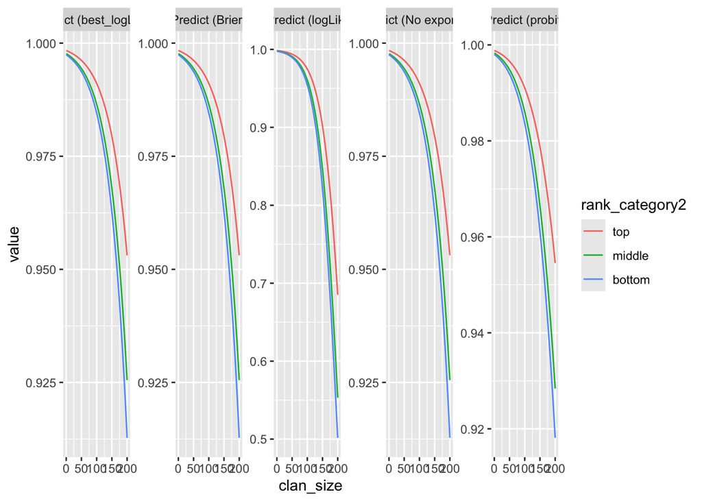

```r
## Best model based on log-likelihood
best_logLik  <- fit_exp(x = best_fit_Fsurv$data$exponent[best_fit_Fsurv$data$logLik == max(best_fit_Fsurv$data$logLik)],
                        model = F_surv_mod_logit_poly2,
                        train_data = train_data_Fsurv, verbose = FALSE)
## Best logit model based on Brier score
best_Brier  <- fit_exp(x = best_fit_Fsurv$data$exponent[best_fit_Fsurv$data$Brier == min(best_fit_Fsurv$data$Brier)],
                       model = F_surv_mod_logit_poly2,
                       train_data = train_data_Fsurv, verbose = FALSE)
## Best probit model based on Brier score
best_probit <- fit_exp(x = probit_fit_Fsurv$data$exponent[probit_fit_Fsurv$data$Brier == min(probit_fit_Fsurv$data$Brier)],
                       model = probit_mod_Fsurv,
                       train_data = train_data_Fsurv, verbose = FALSE)
## Best model based on log loss function
best_logLoss  <- fit_exp(x = best_fit_Fsurv$data$exponent[best_fit_Fsurv$data$logLoss == min(best_fit_Fsurv$data$logLoss)],
                         model = F_surv_mod_logit_poly2,
                         train_data = train_data_Fsurv, verbose = FALSE)
## Model with no exponent
noexp  <- fit_exp(x = 1, model = F_surv_mod_logit_poly2,
                  train_data = train_data_Fsurv, verbose = FALSE)

plot_data <- expand.grid(start_clan = "A", clan_size = 0:200, after1y_effort_all = 1,
                         rank_category2 = c("top", "middle", "bottom"), age = 120, months = 12) %>%
  mutate(`Predict (logLik)` = as.numeric(predict(best_logLik, newdata = ., type = "response", re.form = NA)),
         `Predict (Brier)` = as.numeric(predict(best_Brier, newdata = ., type = "response", re.form = NA)),
         `Predict (best_logLoss)` = as.numeric(predict(best_logLoss, newdata = ., type = "response", re.form = NA)),
         `Predict (probit)` = as.numeric(predict(best_probit, newdata = ., type = "response", re.form = NA)),
         `Predict (No exponent)` = as.numeric(predict(noexp, newdata = ., type = "response", re.form = NA))) %>%
  tidyr::pivot_longer(starts_with("Pred"))

ggplot(data = plot_data) +
  geom_line(aes(x = clan_size, y = value, colour = rank_category2)) +
  facet_wrap(facets = ~name, scales = "free_y", nrow = 1)
```

### Male pre-dispersal survival

```r
set.seed(10)
whole_data_PreMsurv <- model_data$PreM_surv_data |>
  ## Filter out not full years
  dplyr::filter(year <= end_yr) |>
  ## Add rank category (top, middle, bottom)
  dplyr::mutate(rank_category2 = case_when(nat_rank_std >= 1/3 ~ "top",
                                           nat_rank_std < -1/3 ~ "bottom",
                                           TRUE ~ "middle")) |>
  dplyr::select(surv, year, rank_category2, age, clan_size, start_clan)

test_sample <- sample(1:nrow(whole_data_PreMsurv), size = as.integer(nrow(whole_data_PreMsurv)*0.05), replace = FALSE)

train_data_PreMsurv <- whole_data_PreMsurv[-test_sample, ]
test_data_PreMsurv  <- whole_data_PreMsurv[test_sample, ] |>
  rename(event = surv)
```

Test different polynomes for age. Anything above 2nd order polynomial creates unrealistic biological patterns and are ignored.

```r
null_mod <- spaMM::fitme(surv ~ 1 + (1|start_clan:year),
                         data = train_data_PreMsurv,
                         method = "PQL/L", family = binomial(link = "logit"))

PreM_surv_mod_logit_poly1 <- spaMM::fitme(surv ~ poly(age, 1)*rank_category2 +
                                            clan_size +
                                            clan_size:rank_category2 + start_clan + (1|start_clan:year),
                                          data = train_data_PreMsurv,
                                          method = "PQL/L", family = binomial(link = "logit"))

PreM_surv_mod_logit_poly2 <- spaMM::fitme(surv ~ poly(age, 2)*rank_category2 +
                                            clan_size +
                                            clan_size:rank_category2 + start_clan + (1|start_clan:year),
                                          data = train_data_PreMsurv,
                                          method = "PQL/L", family = binomial(link = "logit"))
```

Compare polynomes and null model based on predictive accuracy.

```r
polynome_mods_PreMsurv <- list(null_mod, PreM_surv_mod_logit_poly1, PreM_surv_mod_logit_poly2)
polynome_accuracy_PreMsurv <- purrr::map2_dfr(.x = polynome_mods_PreMsurv, .y = c("null", "poly1", "poly2"), .f = est_accuracy,
                                              test_data = test_data_PreMsurv)
polynome_accuracy_PreMsurv |>
  arrange(Brier)
```

```
## # A tibble: 3 × 4
##   name  logLik logLoss  Brier
##   <chr>  <dbl>   <dbl>  <dbl>
## 1 poly2 -3111.   0.108 0.0229
## 2 poly1 -3121.   0.109 0.0230
## 3 null  -3199.   0.111 0.0231
```

Model with 2nd order polynomes for age has best predictive fit. Look at different exponents for density dependence.

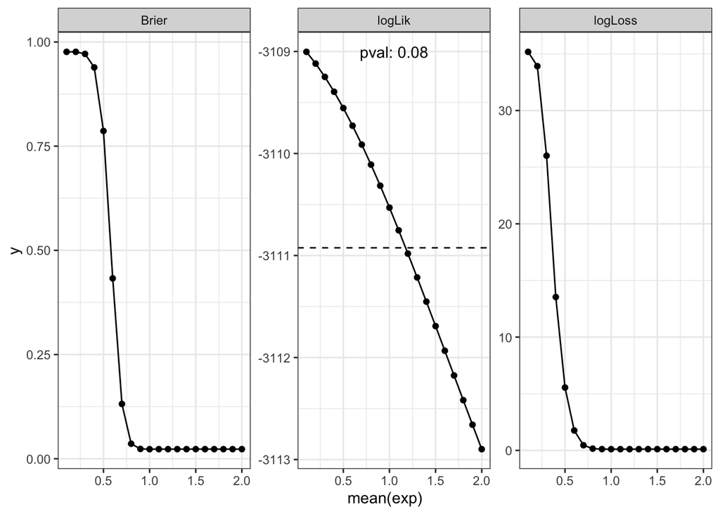

```r
best_fit_PreMsurv <- exp_profiling(exp = seq(0.1, 2, 0.1), PreM_surv_mod_logit_poly2, train_data_PreMsurv, test_data_PreMsurv)
best_fit_PreMsurv$plot
```

```r
dplyr::bind_rows(polynome_accuracy_PreMsurv, best_fit_PreMsurv$data) |>
  dplyr::arrange(Brier)
```

```
## # A tibble: 23 × 5
##    name     logLik logLoss  Brier exponent
##    <chr>     <dbl>   <dbl>  <dbl>    <dbl>
##  1 poly2    -3111.   0.108 0.0229     NA
##  2 Exp: 1   -3111.   0.108 0.0229      1
##  3 Exp: 1.1 -3111.   0.109 0.0230      1.1
##  4 Exp: 1.2 -3111.   0.109 0.0230      1.2
##  5 poly1    -3121.   0.109 0.0230     NA
##  6 Exp: 1.3 -3111.   0.110 0.0230      1.3
##  7 Exp: 1.4 -3111.   0.110 0.0230      1.4
##  8 Exp: 2   -3113.   0.110 0.0230      2
##  9 Exp: 1.9 -3113.   0.110 0.0230      1.9
## 10 Exp: 1.8 -3112.   0.110 0.0230      1.8
## # ℹ 13 more rows
```

Model with no exponent and poly 2 comes out as best. With likelihood profiling, the best model is not significantly different to exponent 1. Check if predictive fit would be better with probit link.

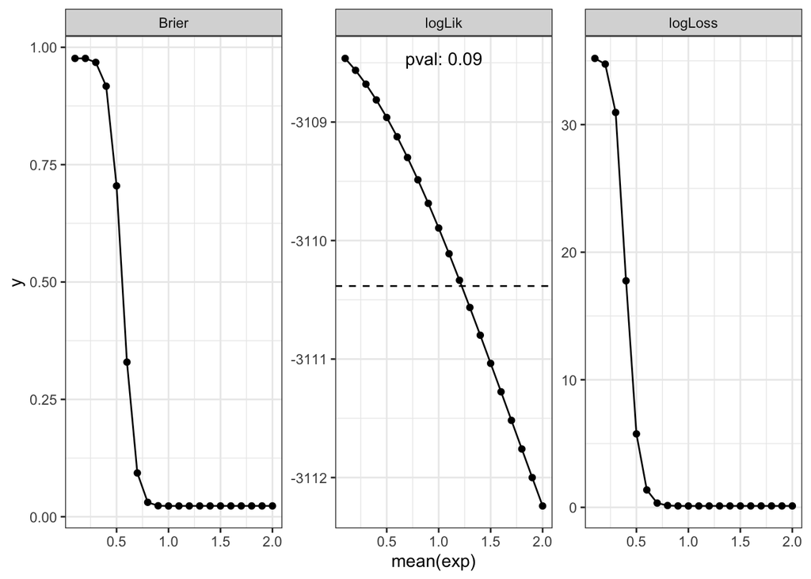

```r
output_table <- best_fit_PreMsurv$data |>
  mutate(link = "logit",
         age_polynome = 2) |>
  bind_rows(polynome_accuracy_PreMsurv |>
              filter(name != "poly2") |>
              mutate(link = c("logit"),
                     age_polynome = c(NA, 1),
                     exponent = c(NA, 1))) |>
  bind_rows(probit_fit_PreMsurv$data |>
              mutate(link = "probit",
                     age_polynome = 2)) |>
  ## Arrange nicely
  select(link, exponent, age_polynome, Brier, logLoss, logLik) |>
  dplyr::arrange(Brier)
output_table
```

```
## # A tibble: 42 × 6
##    link   exponent age_polynome  Brier logLoss logLik
##    <chr>     <dbl>        <dbl>  <dbl>   <dbl>  <dbl>
##  1 probit      1              2 0.0229   0.108 -3110.
##  2 logit       1              2 0.0229   0.108 -3111.
##  3 logit       1.1            2 0.0230   0.109 -3111.
##  4 probit      1.1            2 0.0230   0.109 -3110.
##  5 logit       1.2            2 0.0230   0.109 -3111.
##  6 logit       1              1 0.0230   0.109 -3121.
##  7 probit      1.2            2 0.0230   0.110 -3110.
##  8 logit       1.3            2 0.0230   0.110 -3111.
##  9 probit      1.3            2 0.0230   0.110 -3111.
## 10 logit       1.4            2 0.0230   0.110 -3111.
## # ℹ 32 more rows
```

Best model is probit with age polynome 2 and no exponent.

```r
##Save output to include in supp material
write.csv(output_table |>
            mutate(across(logLik:Brier, \(x) round(x, 4)),
                   n = 1:n()) |>
            ## Only include top 10
            ## Always include null model as well
            filter(n <= 10 | is.na(exponent)) |>
            select(-n),
          here::here("./data/model_accuracy/PreMsurv.csv"), row.names = FALSE)
```

#### Plot

Probit model is best. All models tend to poorly estimate low rank survival. This has the least amount of data.

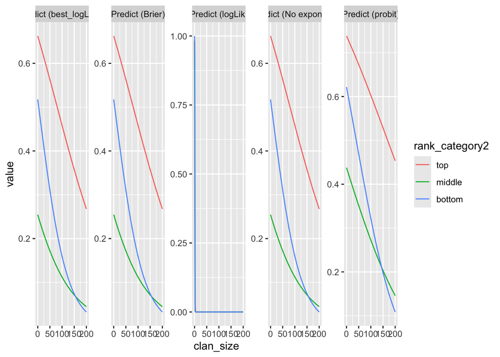

```r
## Best model based on log-likelihood
best_logLik  <- fit_exp(x = best_fit_PreMsurv$data$exponent[best_fit_PreMsurv$data$logLik == max(best_fit_PreMsurv$data$logLik)],
                        model = PreM_surv_mod_logit_poly2,
                        train_data = train_data_PreMsurv, verbose = FALSE)
## Best logit model based on Brier score
best_Brier  <- fit_exp(x = best_fit_PreMsurv$data$exponent[best_fit_PreMsurv$data$Brier == min(best_fit_PreMsurv$data$Brier)],
                       model = PreM_surv_mod_logit_poly2,
                       train_data = train_data_PreMsurv, verbose = FALSE)
## Best probit model based on Brier score
best_probit <- fit_exp(x = probit_fit_PreMsurv$data$exponent[probit_fit_PreMsurv$data$Brier == min(probit_fit_PreMsurv$data$Brier)],
                       model = probit_mod_PreMsurv,
                       train_data = train_data_PreMsurv, verbose = FALSE)
## Best model based on log loss function
best_logLoss  <- fit_exp(x = best_fit_PreMsurv$data$exponent[best_fit_PreMsurv$data$logLoss == min(best_fit_PreMsurv$data$logLoss)],
                         model = PreM_surv_mod_logit_poly2,
                         train_data = train_data_PreMsurv, verbose = FALSE)
## Model with no exponent
noexp  <- fit_exp(x = 1, model = PreM_surv_mod_logit_poly2,
                  train_data = train_data_PreMsurv, verbose = FALSE)

plot_data <- expand.grid(start_clan = "A", clan_size = 0:200, after1y_effort_all = 1,
                         rank_category2 = c("top", "middle", "bottom"), age = 120, months = 12) %>%
  mutate(`Predict (logLik)` = as.numeric(predict(best_logLik, newdata = ., type = "response", re.form = NA)),
         `Predict (Brier)` = as.numeric(predict(best_Brier, newdata = ., type = "response", re.form = NA)),
         `Predict (best_logLoss)` = as.numeric(predict(best_logLoss, newdata = ., type = "response", re.form = NA)),
         `Predict (probit)` = as.numeric(predict(best_probit, newdata = ., type = "response", re.form = NA)),
         `Predict (No exponent)` = as.numeric(predict(noexp, newdata = ., type = "response", re.form = NA))) %>%
  tidyr::pivot_longer(starts_with("Pred"))

ggplot(data = plot_data) +
  geom_line(aes(x = clan_size, y = value, colour = rank_category2)) +
  facet_wrap(facets = ~name, scales = "free_y", nrow = 1)
```

### Male post-dispersal survival

```r
set.seed(10)
whole_data_PostMsurv <- model_data$PostM_surv_data |>
  ## Filter out not full years
  dplyr::filter(year <= end_yr & !is.na(post_dispersal_status)) |>
  ## Add rank category (top, middle, bottom)
  dplyr::mutate(rank_category2 = case_when(nat_rank_std >= 1/3 ~ "top",
                                           nat_rank_std < -1/3 ~ "bottom",
                                           TRUE ~ "middle")) |>
  dplyr::select(surv, year, rank_category2, post_dispersal_status, age, clan_size, start_clan)

test_sample <- sample(1:nrow(whole_data_PostMsurv), size = as.integer(nrow(whole_data_PostMsurv)*0.05), replace = FALSE)

train_data_PostMsurv <- whole_data_PostMsurv[-test_sample, ]
test_data_PostMsurv  <- whole_data_PostMsurv[test_sample, ] |>
  rename(event = surv)
```

Only consider 1st and 2nd order polynomials. Anything higher creates biologically unrealistic patterns (e.g. survival declines and then increase with age).

```r
null_mod <- spaMM::fitme(surv ~ 1 + (1|start_clan:year),
                         data = train_data_PreMsurv,
                         method = "PQL/L", family = binomial(link = "logit"))

PostM_surv_mod_logit_poly1 <- spaMM::fitme(surv ~ poly(age, 1)*post_dispersal_status +
                                             clan_size +
                                             start_clan + (1|start_clan:year),
                                           data = train_data_PostMsurv,
                                           method = "PQL/L", family = binomial(link = "logit"))

PostM_surv_mod_logit_poly2 <- spaMM::fitme(surv ~ poly(age, 2)*post_dispersal_status +
                                             clan_size +
                                             start_clan + (1|start_clan:year),
                                           data = train_data_PostMsurv,
                                           method = "PQL/L", family = binomial(link = "logit"))
```

Compare polynomes and null model based on predictive accuracy.

```r
polynome_mods_PostMsurv <- list(null_mod, PostM_surv_mod_logit_poly1, PostM_surv_mod_logit_poly2)
polynome_accuracy_PostMsurv <- purrr::map2_dfr(.x = polynome_mods_PostMsurv, .y = c("null", "poly1", "poly2"), .f = est_accuracy,
                                               test_data = test_data_PostMsurv)
polynome_accuracy_PostMsurv |>
  arrange(Brier)
```

```
## # A tibble: 3 × 4
##   name  logLik logLoss   Brier
##   <chr>  <dbl>   <dbl>   <dbl>
## 1 poly2 -1541.  0.0479 0.00800
## 2 poly1 -1542.  0.0477 0.00801
## 3 null  -3199.  0.0561 0.00850
```

Model w/ 2nd order polynome appears best.

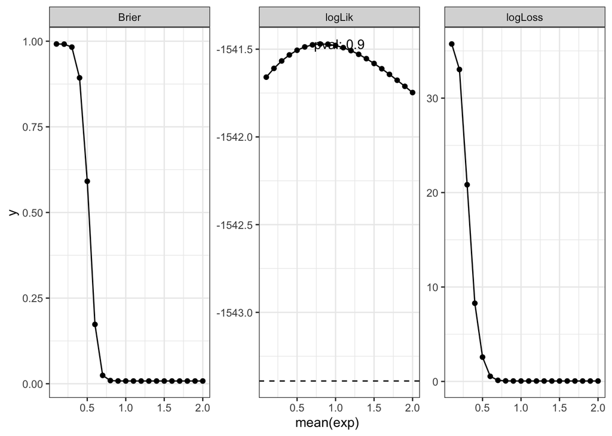

```r
best_fit_PostMsurv <- exp_profiling(exp = seq(0.1, 2, 0.1), PostM_surv_mod_logit_poly2, train_data_PostMsurv, test_data_PostMsurv)
best_fit_PostMsurv$plot
```

```r
dplyr::bind_rows(polynome_accuracy_PostMsurv, best_fit_PostMsurv$data) |>
  dplyr::arrange(Brier)
```

```
## # A tibble: 23 × 5
##    name     logLik logLoss   Brier exponent
##    <chr>     <dbl>   <dbl>   <dbl>    <dbl>
##  1 Exp: 1.4 -1542.  0.0470 0.00797      1.4
##  2 Exp: 1.3 -1542.  0.0470 0.00797      1.3
##  3 Exp: 1.5 -1542.  0.0470 0.00797      1.5
##  4 Exp: 1.6 -1542.  0.0470 0.00797      1.6
##  5 Exp: 1.7 -1542.  0.0470 0.00797      1.7
##  6 Exp: 1.2 -1542.  0.0471 0.00797      1.2
##  7 Exp: 1.8 -1542.  0.0470 0.00797      1.8
##  8 Exp: 1.9 -1542.  0.0470 0.00797      1.9
##  9 Exp: 2   -1542.  0.0471 0.00797      2
## 10 Exp: 1.1 -1541.  0.0473 0.00797      1.1
## # ℹ 13 more rows
```

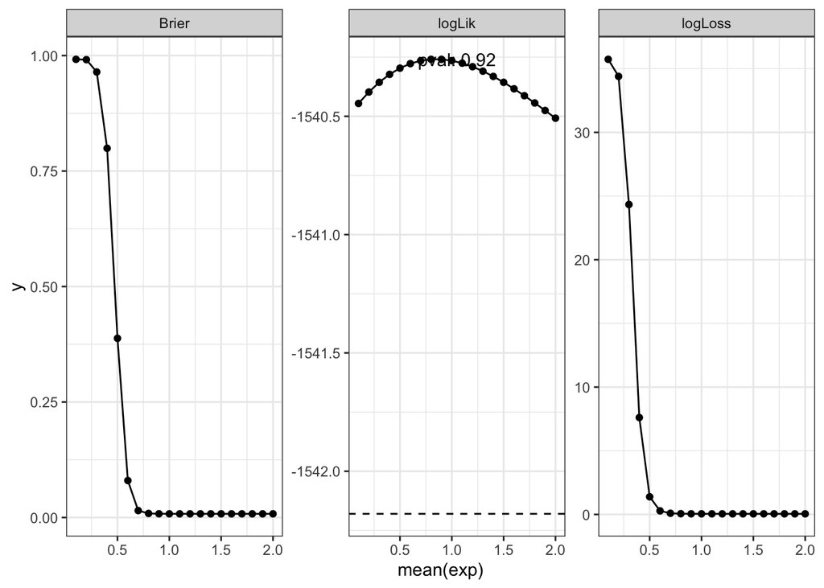

```r
output_table <- best_fit_PostMsurv$data |>
  mutate(link = "logit",
         age_polynome = 2) |>
  bind_rows(polynome_accuracy_PostMsurv |>
              filter(name != "poly2") |>
              mutate(link = "logit",
                     age_polynome = c(NA, 1),
                     exponent = c(NA, 1))) |>
  bind_rows(probit_fit_PostMsurv$data |>
              mutate(link = "probit",
                     age_polynome = 2)) |>
  ## Arrange nicely
  select(link, exponent, age_polynome, Brier, logLoss, logLik) |>
  dplyr::arrange(Brier)
output_table
```

```
## # A tibble: 42 × 6
##    link   exponent age_polynome   Brier logLoss logLik
##    <chr>     <dbl>        <dbl>   <dbl>   <dbl>  <dbl>
##  1 logit       1.4            2 0.00797  0.0470 -1542.
##  2 logit       1.3            2 0.00797  0.0470 -1542.
##  3 logit       1.5            2 0.00797  0.0470 -1542.
##  4 logit       1.6            2 0.00797  0.0470 -1542.
##  5 logit       1.7            2 0.00797  0.0470 -1542.
##  6 logit       1.2            2 0.00797  0.0471 -1542.
##  7 logit       1.8            2 0.00797  0.0470 -1542.
##  8 logit       1.9            2 0.00797  0.0470 -1542.
##  9 logit       2              2 0.00797  0.0471 -1542.
## 10 probit      1.4            2 0.00797  0.0472 -1540.
## # ℹ 32 more rows
```

Logit with slight exponent (1.4) and 2nd order polynomial is best.

```r
##Save output to include in supp material
write.csv(output_table |>
            mutate(across(logLik:Brier, \(x) round(x, 4)),
                   n = 1:n()) |>
            ## Only include top 10
            ## Always include null model as well
            filter(n <= 10 | is.na(exponent)) |>
            select(-n),
          here::here("./data/model_accuracy/PostMsurv.csv"), row.names = FALSE)
```

#### Plot

Best model (with 1.4 exponent) is slightly less steep than standard model.

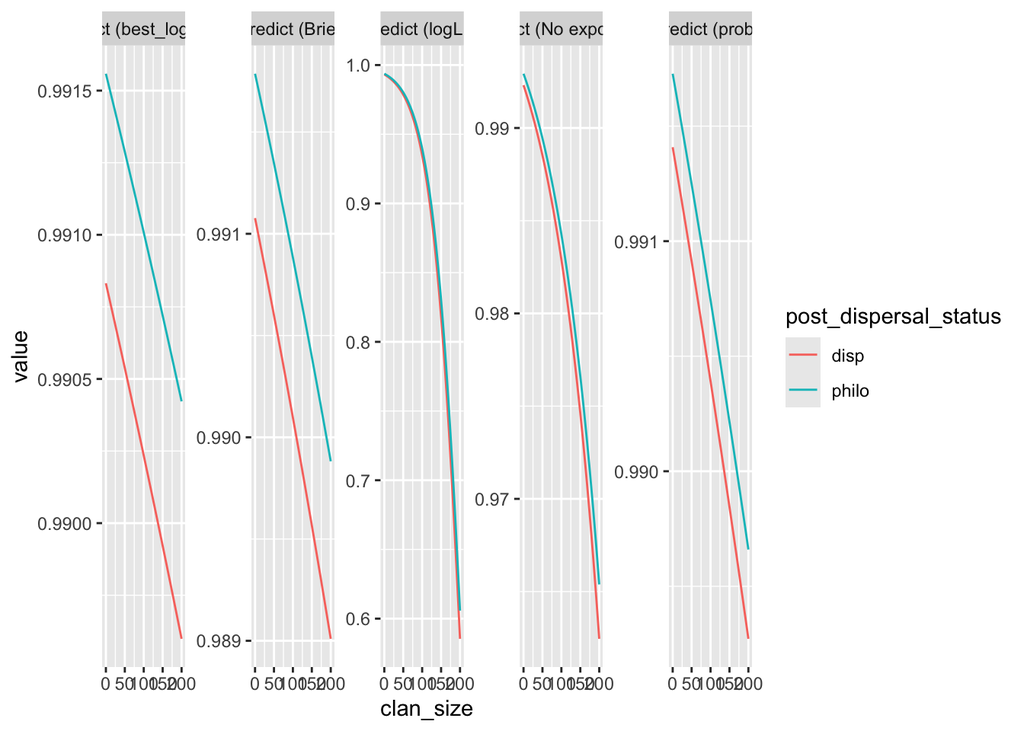

```r
## Best model based on log-likelihood
best_logLik  <- fit_exp(x = best_fit_PostMsurv$data$exponent[best_fit_PostMsurv$data$logLik == max(best_fit_PostMsurv$data$logLik)],
                        model = PostM_surv_mod_logit_poly2,
                        train_data = train_data_PostMsurv, verbose = FALSE)
## Best logit model based on Brier score
best_Brier  <- fit_exp(x = best_fit_PostMsurv$data$exponent[best_fit_PostMsurv$data$Brier == min(best_fit_PostMsurv$data$Brier)],
                       model = PostM_surv_mod_logit_poly2,
                       train_data = train_data_PostMsurv, verbose = FALSE)
## Best probit model based on Brier score
best_probit <- fit_exp(x = probit_fit_PostMsurv$data$exponent[probit_fit_PostMsurv$data$Brier == min(probit_fit_PostMsurv$data$Brier)],
                       model = probit_mod_PostMsurv,
                       train_data = train_data_PostMsurv, verbose = FALSE)
## Best model based on log loss function
best_logLoss  <- fit_exp(x = best_fit_PostMsurv$data$exponent[best_fit_PostMsurv$data$logLoss == min(best_fit_PostMsurv$data$logLoss)],
                         model = PostM_surv_mod_logit_poly2,
                         train_data = train_data_PostMsurv, verbose = FALSE)
## Model with no exponent
noexp  <- fit_exp(x = 1, model = PostM_surv_mod_logit_poly2,
                  train_data = train_data_PostMsurv, verbose = FALSE)

plot_data <- expand.grid(start_clan = "A", clan_size = 0:200, after1y_effort_all = 1,
                         post_dispersal_status = c("disp", "philo"), age = 120, months = 12) %>%
  mutate(`Predict (logLik)` = as.numeric(predict(best_logLik, newdata = ., type = "response", re.form = NA)),
         `Predict (Brier)` = as.numeric(predict(best_Brier, newdata = ., type = "response", re.form = NA)),
         `Predict (best_logLoss)` = as.numeric(predict(best_logLoss, newdata = ., type = "response", re.form = NA)),
         `Predict (probit)` = as.numeric(predict(best_probit, newdata = ., type = "response", re.form = NA)),
         `Predict (No exponent)` = as.numeric(predict(noexp, newdata = ., type = "response", re.form = NA))) %>%
  tidyr::pivot_longer(starts_with("Pred"))

ggplot(data = plot_data) +
  geom_line(aes(x = clan_size, y = value, colour = post_dispersal_status)) +
  facet_wrap(facets = ~name, scales = "free_y", nrow = 1)
```

### Primiparous reproduction

```r
set.seed(10)
whole_data_Fprimi <- model_data$F_repro_primi |>
  ## Filter out not full years
  dplyr::filter(year <= end_yr) |>
  ## Add rank category (top, middle, bottom)
  dplyr::mutate(rank_category2 = case_when(nat_rank_std >= 1/3 ~ "top",
                                           nat_rank_std < -1/3 ~ "bottom",
                                           TRUE ~ "middle")) |>
  dplyr::select(repro, year, rank_category2, clan_size, start_clan, after1y_effort_all, months)

test_sample <- sample(1:nrow(whole_data_Fprimi), size = as.integer(nrow(whole_data_Fprimi)*0.05), replace = FALSE)

train_data_Fprimi <- whole_data_Fprimi[-test_sample, ]
test_data_Fprimi  <- whole_data_Fprimi[test_sample, ] |>
  rename(event = repro)
```

```r
null_mod <- spaMM::fitme(repro ~ after1y_effort_all + (1|start_clan:year),
                         data = train_data_Fprimi,
                         method = "PQL/L", family = binomial(link = "logit"))

## We include an atan transform on month to allow for higher possibility of reproduction at younger ages
F_repro_primi_mod_logit <- spaMM::fitme(repro ~ atan(months)*rank_category2 +
                                          rank_category2*clan_size +
                                          after1y_effort_all + start_clan + (1|start_clan:year),
                                        data = train_data_Fprimi,
                                        method = "PQL/L", family = binomial(link = "logit"))
```

Compare our different atan models

```r
mods_Fprimi <- list(null_mod, F_repro_primi_mod_logit)
mods_accuracy_Fprimi <- purrr::map2_dfr(.x = mods_Fprimi, .y = c("null", "atan"),
                                        .f = est_accuracy,
                                              test_data = test_data_Fprimi)
mods_accuracy_Fprimi |>
  arrange(Brier)
```

```
## # A tibble: 2 × 4
##   name  logLik logLoss   Brier
##   <chr>  <dbl>   <dbl>   <dbl>
## 1 atan  -1586.  0.0438 0.00881
## 2 null  -1900.  0.0513 0.00883
```

Fit different exponents and compare to null model

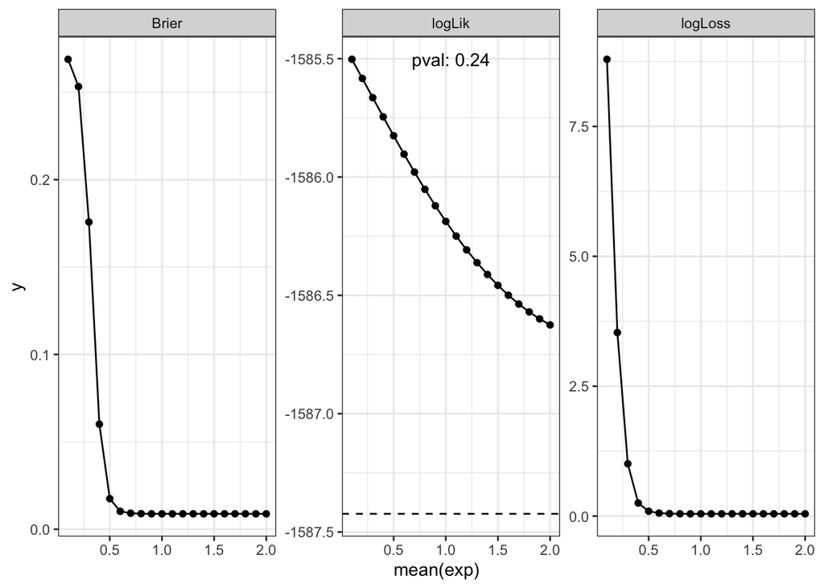

```r
best_fit_Fprimi <- exp_profiling(exp = seq(0.1, 2, 0.1),
                                 F_repro_primi_mod_logit,
                                 train_data_Fprimi, test_data_Fprimi)
best_fit_Fprimi$plot
```

```r
est_accuracy(null_mod, test_data_Fprimi, name = "null") |>
  dplyr::bind_rows(best_fit_Fprimi$data) |>
  arrange(Brier)
```

```
## # A tibble: 21 × 5
##    name     logLik logLoss   Brier exponent
##    <chr>     <dbl>   <dbl>   <dbl>    <dbl>
##  1 Exp: 1   -1586.  0.0438 0.00881      1
##  2 Exp: 1.1 -1586.  0.0440 0.00881      1.1
##  3 Exp: 2   -1587.  0.0442 0.00882      2
##  4 Exp: 1.9 -1587.  0.0442 0.00882      1.9
##  5 Exp: 1.8 -1587.  0.0443 0.00882      1.8
##  6 Exp: 1.2 -1586.  0.0442 0.00882      1.2
##  7 Exp: 1.7 -1587.  0.0443 0.00882      1.7
##  8 Exp: 1.6 -1586.  0.0443 0.00882      1.6
##  9 Exp: 1.3 -1586.  0.0443 0.00882      1.3
## 10 Exp: 1.5 -1586.  0.0443 0.00883      1.5
## # ℹ 11 more rows
```

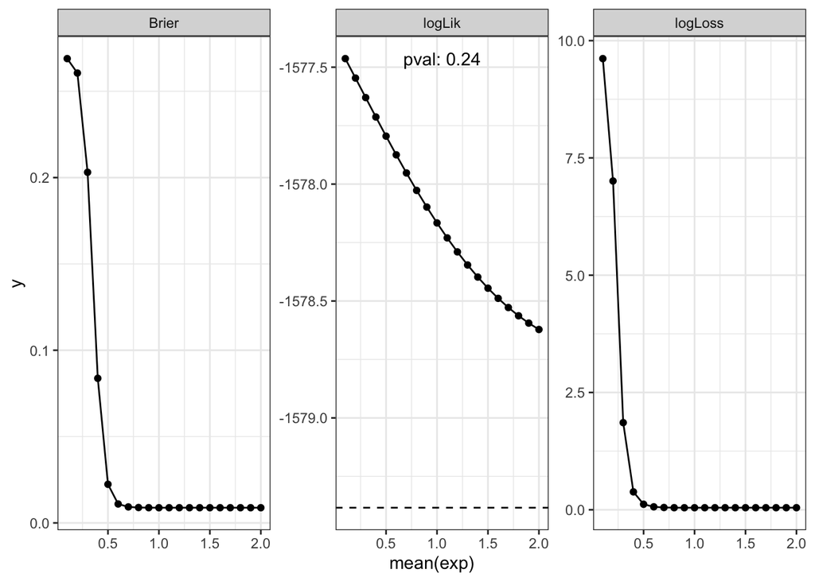

```r
output_table <- best_fit_Fprimi$data |>
  mutate(link = "logit") |>
  bind_rows(probit_fit_Fprimi$data |>
              mutate(link = "probit")) |>
  bind_rows(est_accuracy(null_mod, test_data_Fprimi, name = "null") |>
              mutate(link = "logit")) |>
  ## Arrange nicely
  select(link, exponent, Brier, logLoss, logLik) |>
  dplyr::arrange(Brier)
output_table
```

```
## # A tibble: 41 × 5
##    link   exponent   Brier logLoss logLik
##    <chr>     <dbl>   <dbl>   <dbl>  <dbl>
##  1 probit      1   0.00881  0.0435 -1578.
##  2 probit      1.1 0.00881  0.0438 -1578.
##  3 probit      2   0.00881  0.0440 -1579.
##  4 probit      1.9 0.00881  0.0440 -1579.
##  5 probit      1.8 0.00881  0.0440 -1579.
##  6 logit       1   0.00881  0.0438 -1586.
##  7 probit      1.2 0.00881  0.0439 -1578.
##  8 probit      1.7 0.00881  0.0440 -1579.
##  9 probit      1.6 0.00881  0.0441 -1578.
## 10 probit      1.3 0.00881  0.0440 -1578.
## # ℹ 31 more rows
```

Probit model with no exponent is best.

```r
##Save output to include in supp material
write.csv(output_table |>
            mutate(across(logLik:Brier, \(x) round(x, 4)),
                   n = 1:n()) |>
            ## Only include top 10
            ## Always include null model as well
            filter(n <= 10 | is.na(exponent)) |>
            select(-n),
          here::here("./data/model_accuracy/Fprimirepro.csv"), row.names = FALSE)
```

#### Plot

Probit model creates larger difference between top females and others in DD effects.

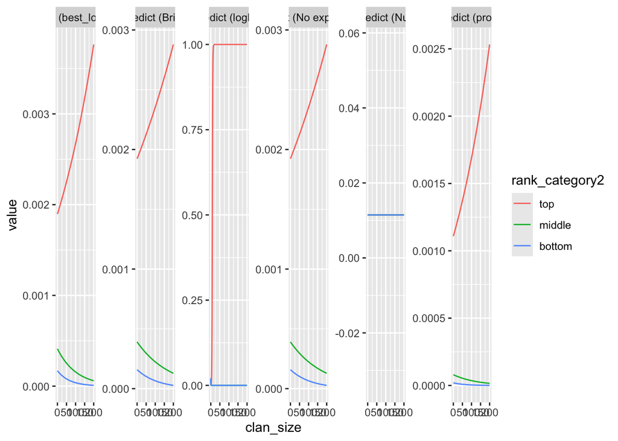

```r
## Best model based on log-likelihood
best_logLik  <- fit_exp(x = best_fit_Fprimi$data$exponent[best_fit_Fprimi$data$logLik == max(best_fit_Fprimi$data$logLik)],
                        model = F_repro_primi_mod_logit,
                        train_data = train_data_Fprimi, verbose = FALSE)
## Best logit model based on Brier score
best_Brier  <- fit_exp(x = best_fit_Fprimi$data$exponent[best_fit_Fprimi$data$Brier == min(best_fit_Fprimi$data$Brier)],
                       model = F_repro_primi_mod_logit,
                       train_data = train_data_Fprimi, verbose = FALSE)
## Best probit model based on Brier score
best_probit <- fit_exp(x = probit_fit_Fprimi$data$exponent[probit_fit_Fprimi$data$Brier == min(probit_fit_Fprimi$data$Brier)],
                       model = probit_mod_Fprimi,
                       train_data = train_data_Fprimi, verbose = FALSE)
## Best model based on log loss function
best_logLoss  <- fit_exp(x = best_fit_Fprimi$data$exponent[best_fit_Fprimi$data$logLoss == min(best_fit_Fprimi$data$logLoss)],
                         model = F_repro_primi_mod_logit,
                         train_data = train_data_Fprimi, verbose = FALSE)
## Model with no exponent
noexp  <- fit_exp(x = 1, model = F_repro_primi_mod_logit,
                  train_data = train_data_Fprimi, verbose = FALSE)

plot_data <- expand.grid(start_clan = "A", clan_size = 0:200, after1y_effort_all = 1,
                         rank_category2 = c("top", "middle", "bottom"), age = 120, months = 12) %>%
  mutate(`Predict (logLik)` = as.numeric(predict(best_logLik, newdata = ., type = "response", re.form = NA)),
         `Predict (Brier)` = as.numeric(predict(best_Brier, newdata = ., type = "response", re.form = NA)),
         `Predict (best_logLoss)` = as.numeric(predict(best_logLoss, newdata = ., type = "response", re.form = NA)),
         `Predict (probit)` = as.numeric(predict(best_probit, newdata = ., type = "response", re.form = NA)),
         `Predict (No exponent)` = as.numeric(predict(noexp, newdata = ., type = "response", re.form = NA)),
         `Predict (Null)` = as.numeric(predict(null_mod, newdata = ., type = "response", re.form = NA))) %>%
  tidyr::pivot_longer(starts_with("Pred"))

ggplot(data = plot_data) +
  geom_line(aes(x = clan_size, y = value, colour = rank_category2)) +
  facet_wrap(facets = ~name, scales = "free_y", nrow = 1)
```

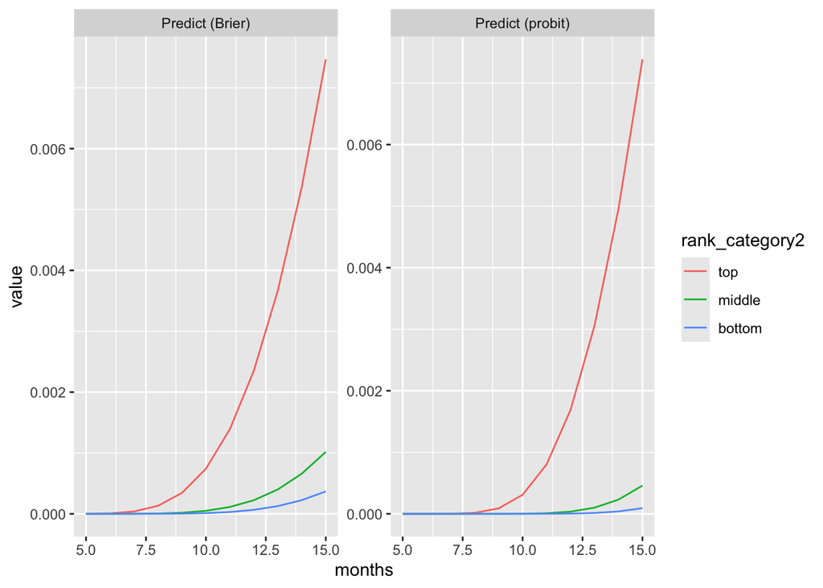

```r
plot_data <- expand.grid(start_clan = "A", clan_size = 100, after1y_effort_all = 1,
                         rank_category2 = c("top", "middle", "bottom"), months = 5:15) %>%
  mutate(`Predict (Brier)` = as.numeric(predict(best_Brier, newdata = ., type = "response", re.form = NA)),
         `Predict (probit)` = as.numeric(predict(best_probit, newdata = ., type = "response", re.form = NA))) %>%
  tidyr::pivot_longer(starts_with("Pred"))

ggplot(data = plot_data) +
  geom_line(aes(x = months, y = value, colour = rank_category2)) +
  facet_wrap(facets = ~name, scales = "free_y", nrow = 1)
```

### Multiparous reproduction

```r
set.seed(10)
whole_data_Fnonprimi <- model_data$F_repro_nonprimi |>
  ## Filter out not full years
  dplyr::filter(year <= end_yr) |>
  ## Add rank category (top, middle, bottom)
  dplyr::mutate(rank_category2 = case_when(nat_rank_std >= 1/3 ~ "top",
                                           nat_rank_std < -1/3 ~ "bottom",
                                           TRUE ~ "middle")) |>
  dplyr::select(repro, year, rank_category2, clan_size, start_clan, after1y_effort_all, months, age)

test_sample <- sample(1:nrow(whole_data_Fnonprimi), size = as.integer(nrow(whole_data_Fnonprimi)*0.05), replace = FALSE)

train_data_Fnonprimi <- whole_data_Fnonprimi[-test_sample, ]
test_data_Fnonprimi  <- whole_data_Fnonprimi[test_sample, ] |>
  rename(event = repro)
```

```r
null_mod <- spaMM::fitme(repro ~ after1y_effort_all + (1|start_clan:year),
                         data = train_data_Fnonprimi,
                         method = "PQL/L", family = binomial(link = "logit"))

F_repro_nonprimi_mod_logit <- spaMM::fitme(repro ~ atan(months)*rank_category2 + atan(months)*age +
                                             clan_size*rank_category2 + after1y_effort_all + start_clan + (1|start_clan:year),
                                           data = train_data_Fnonprimi,
                                           method = "PQL/L", family = binomial(link = "logit"))
```

Compare our different atan models

```r
mods_Fnonprimi <- list(null_mod, F_repro_nonprimi_mod_logit)
mods_accuracy_Fnonprimi <- purrr::map2_dfr(.x = mods_Fnonprimi, .y = c("null", "atan"),
                                        .f = est_accuracy,
                                              test_data = test_data_Fnonprimi)
mods_accuracy_Fnonprimi |>
  arrange(Brier)
```

```
## # A tibble: 2 × 4
##   name  logLik logLoss  Brier
##   <chr>  <dbl>   <dbl>  <dbl>
## 1 atan  -3102.   0.140 0.0336
## 2 null  -3435.   0.155 0.0347
```

Fit different exponents and compare to null model

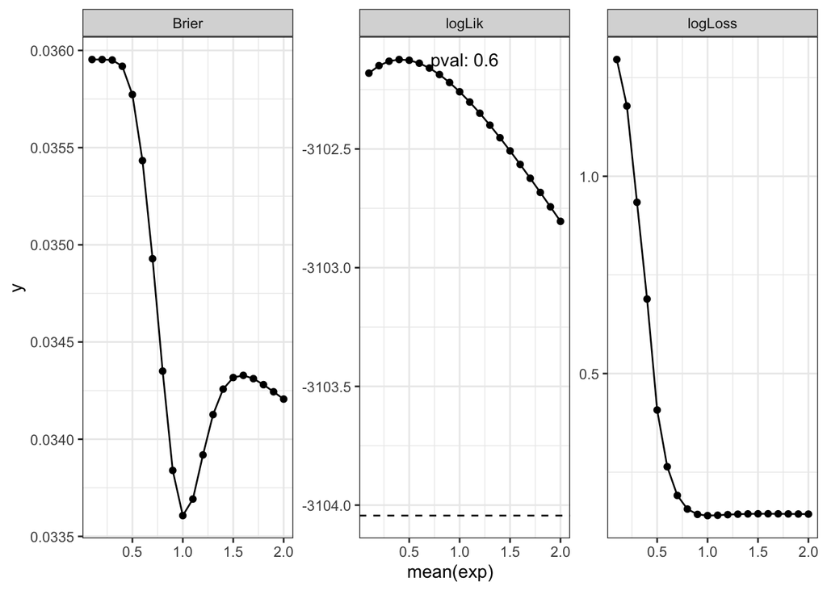

```r
best_fit_Fnonprimi <- exp_profiling(exp = seq(0.1, 2, 0.1),
                                    F_repro_nonprimi_mod_logit,
                                    train_data_Fnonprimi, test_data_Fnonprimi)
best_fit_Fnonprimi$plot
```

```r
est_accuracy(null_mod, test_data_Fnonprimi, name = "null") |>
  dplyr::bind_rows(best_fit_Fnonprimi$data) |>
  arrange(Brier)
```

```
## # A tibble: 21 × 5
##    name     logLik logLoss  Brier exponent
##    <chr>     <dbl>   <dbl>  <dbl>    <dbl>
##  1 Exp: 1   -3102.   0.140 0.0336      1
##  2 Exp: 1.1 -3102.   0.141 0.0337      1.1
##  3 Exp: 0.9 -3102.   0.143 0.0338      0.9
##  4 Exp: 1.2 -3102.   0.142 0.0339      1.2
##  5 Exp: 1.3 -3102.   0.144 0.0341      1.3
##  6 Exp: 2   -3103.   0.144 0.0342      2
##  7 Exp: 1.9 -3103.   0.144 0.0342      1.9
##  8 Exp: 1.4 -3102.   0.144 0.0343      1.4
##  9 Exp: 1.8 -3103.   0.144 0.0343      1.8
## 10 Exp: 1.7 -3103.   0.144 0.0343      1.7
## # ℹ 11 more rows
```

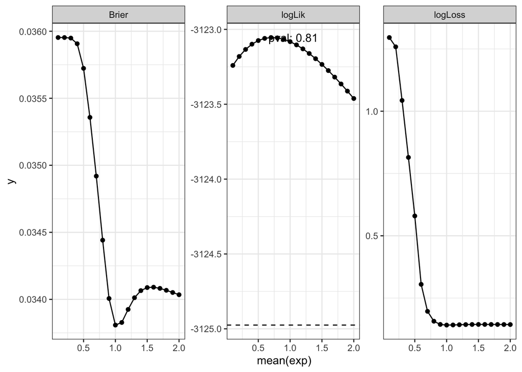

```r
output_table <- best_fit_Fnonprimi$data |>
  mutate(link = "logit") |>
  bind_rows(probit_fit_Fnonprimi$data |>
              mutate(link = "probit")) |>
  bind_rows(est_accuracy(null_mod, test_data_Fnonprimi, name = "null") |>
              mutate(link = "logit")) |>
  ## Arrange nicely
  select(link, exponent, Brier, logLoss, logLik) |>
  dplyr::arrange(Brier)
output_table
```

```
## # A tibble: 41 × 5
##    link   exponent  Brier logLoss logLik
##    <chr>     <dbl>  <dbl>   <dbl>  <dbl>
##  1 logit       1   0.0336   0.140 -3102.
##  2 logit       1.1 0.0337   0.141 -3102.
##  3 probit      1   0.0338   0.141 -3123.
##  4 probit      1.1 0.0338   0.142 -3123.
##  5 logit       0.9 0.0338   0.143 -3102.
##  6 logit       1.2 0.0339   0.142 -3102.
##  7 probit      1.2 0.0339   0.143 -3123.
##  8 probit      0.9 0.0340   0.144 -3123.
##  9 probit      1.3 0.0340   0.144 -3123.
## 10 probit      2   0.0340   0.144 -3123.
## # ℹ 31 more rows
```

Logit model with no exponent is best.

```r
##Save output to include in supp material
write.csv(output_table |>
            mutate(across(logLik:Brier, \(x) round(x, 4)),
                   n = 1:n()) |>
            ## Only include top 10
            ## Always include null model as well
            filter(n <= 10 | is.na(exponent)) |>
            select(-n),
          here::here("./data/model_accuracy/Fnonprimirepro.csv"), row.names = FALSE)
```

#### Plot

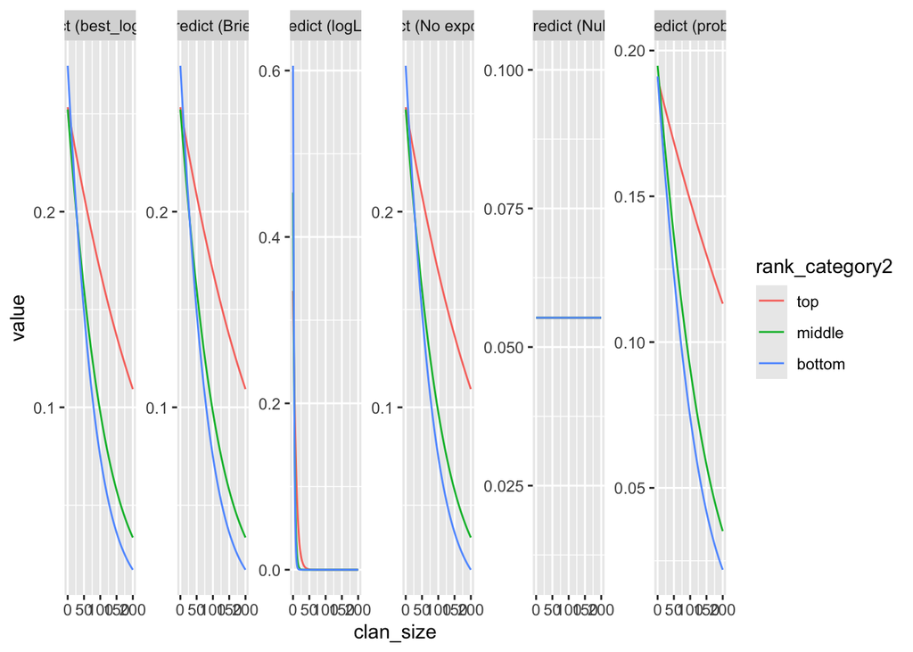

```r
## Best model based on log-likelihood
best_logLik  <- fit_exp(x = best_fit_Fnonprimi$data$exponent[best_fit_Fnonprimi$data$logLik == max(best_fit_Fnonprimi$data$logLik)],
                        model = F_repro_nonprimi_mod_logit,
                        train_data = train_data_Fnonprimi, verbose = FALSE)
## Best logit model based on Brier score
best_Brier  <- fit_exp(x = best_fit_Fnonprimi$data$exponent[best_fit_Fnonprimi$data$Brier == min(best_fit_Fnonprimi$data$Brier)],
                       model = F_repro_nonprimi_mod_logit,
                       train_data = train_data_Fnonprimi, verbose = FALSE)
## Best probit model based on Brier score
best_probit <- fit_exp(x = probit_fit_Fnonprimi$data$exponent[probit_fit_Fnonprimi$data$Brier == min(probit_fit_Fnonprimi$data$Brier)],
                       model = probit_mod_Fnonprimi,
                       train_data = train_data_Fnonprimi, verbose = FALSE)
## Best model based on log loss function
best_logLoss  <- fit_exp(x = best_fit_Fnonprimi$data$exponent[best_fit_Fnonprimi$data$logLoss == min(best_fit_Fnonprimi$data$logLoss)],
                         model = F_repro_nonprimi_mod_logit,
                         train_data = train_data_Fnonprimi, verbose = FALSE)
## Model with no exponent
noexp  <- fit_exp(x = 1, model = F_repro_nonprimi_mod_logit,
                  train_data = train_data_Fnonprimi, verbose = FALSE)

plot_data <- expand.grid(start_clan = "A", clan_size = 0:200, after1y_effort_all = 1,
                         rank_category2 = c("top", "middle", "bottom"), age = 120, months = 12) %>%
  mutate(`Predict (logLik)` = as.numeric(predict(best_logLik, newdata = ., type = "response", re.form = NA)),
         `Predict (Brier)` = as.numeric(predict(best_Brier, newdata = ., type = "response", re.form = NA)),
         `Predict (best_logLoss)` = as.numeric(predict(best_logLoss, newdata = ., type = "response", re.form = NA)),
         `Predict (probit)` = as.numeric(predict(best_probit, newdata = ., type = "response", re.form = NA)),
         `Predict (No exponent)` = as.numeric(predict(noexp, newdata = ., type = "response", re.form = NA)),
         `Predict (Null)` = as.numeric(predict(null_mod, newdata = ., type = "response", re.form = NA))) %>%
  tidyr::pivot_longer(starts_with("Pred"))

ggplot(data = plot_data) +
  geom_line(aes(x = clan_size, y = value, colour = rank_category2)) +
  facet_wrap(facets = ~name, scales = "free_y", nrow = 1)
```

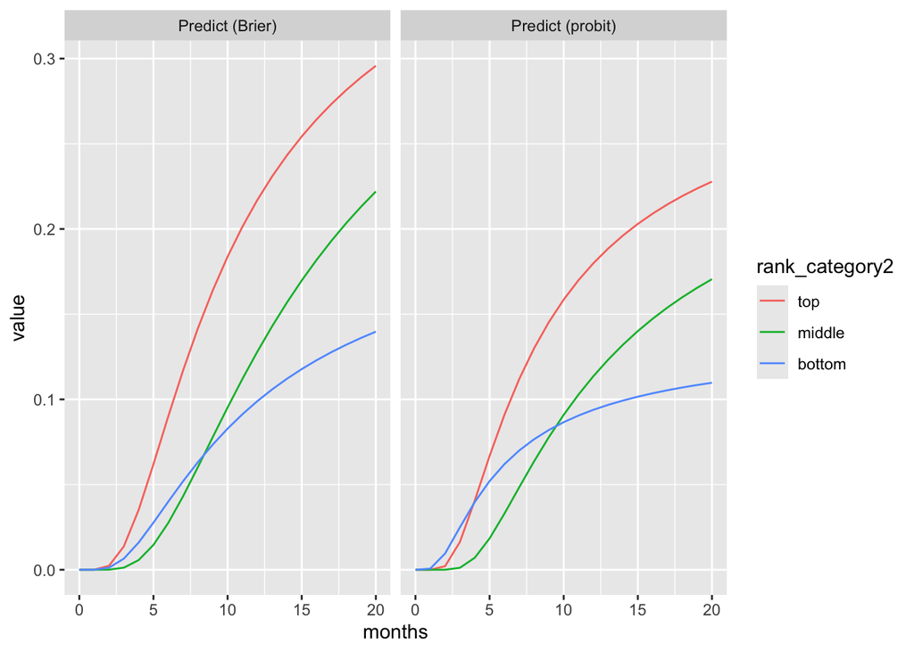

```r
plot_data <- expand.grid(start_clan = "A", clan_size = 100, after1y_effort_all = 1, age = 72,
                         rank_category2 = c("top", "middle", "bottom"), months = 0:20) %>%
  mutate(`Predict (Brier)` = as.numeric(predict(best_Brier, newdata = ., type = "response", re.form = NA)),
         `Predict (probit)` = as.numeric(predict(best_probit, newdata = ., type = "response", re.form = NA))) %>%
  tidyr::pivot_longer(starts_with("Pred"))

ggplot(data = plot_data) +
  geom_line(aes(x = months, y = value, colour = rank_category2)) +
  facet_wrap(facets = ~name, nrow = 1)
```

### Twinning

```r
set.seed(10)
whole_data_twin <- model_data$F_twin_data |>
  ## Filter out not full years
  dplyr::filter(year <= end_yr) |>
  ## Add rank category (top, middle, bottom)
  dplyr::mutate(rank_category2 = case_when(nat_rank_std >= 1/3 ~ "top",
                                           nat_rank_std < -1/3 ~ "bottom",
                                           TRUE ~ "middle")) |>
  dplyr::select(twin, year, rank_category2, age, clan_size, start_clan, after1y_effort_all)

test_sample <- sample(1:nrow(whole_data_twin), size = as.integer(nrow(whole_data_twin)*0.05), replace = FALSE)

train_data_twin <- whole_data_twin[-test_sample, ]
test_data_twin  <- whole_data_twin[test_sample, ] |>
  rename(event = twin)
```

In original tests, we found that the full (large) model with interactive effects of age and clan was not better than null! Here, we’ve considered a simplified model that contains our minimum expected effects: clan size (i.e. density dependence) and social rank.

```r
null_mod <- spaMM::fitme(twin ~ after1y_effort_all + (1|start_clan:year),
                         data = train_data_twin,
                         method = "PQL/L", family = binomial(link = "logit"))

twin_mod_logit <- spaMM::fitme(twin ~ clan_size + rank_category2 + after1y_effort_all + (1|start_clan:year),
                               data = train_data_twin,
                               method = "PQL/L", family = binomial(link = "logit"))

twin_mod_logit_full <- spaMM::fitme(twin ~ age*rank_category2 +
                                      after1y_effort_all +
                                      clan_size*rank_category2 +
                                      start_clan + (1|start_clan:year),
                                    data = train_data_twin,
                                    method = "PQL/L", family = binomial(link = "logit"))
```

Compare different models and null model based on predictive accuracy.

```r
polynome_mods_twin <- list(null_mod, twin_mod_logit, twin_mod_logit_full)
polynome_accuracy_twin <- purrr::map2_dfr(.x = polynome_mods_twin, .y = c("null", "simplemod", "fullmod"), .f = est_accuracy,
                                          test_data = test_data_twin)
polynome_accuracy_twin |>
  arrange(Brier)
```

```
## # A tibble: 3 × 4
##   name      logLik logLoss Brier
##   <chr>      <dbl>   <dbl> <dbl>
## 1 simplemod  -737.   0.628 0.219
## 2 null       -741.   0.629 0.219
## 3 fullmod    -726.   0.653 0.229
```

Fit different exponents and compare to null model

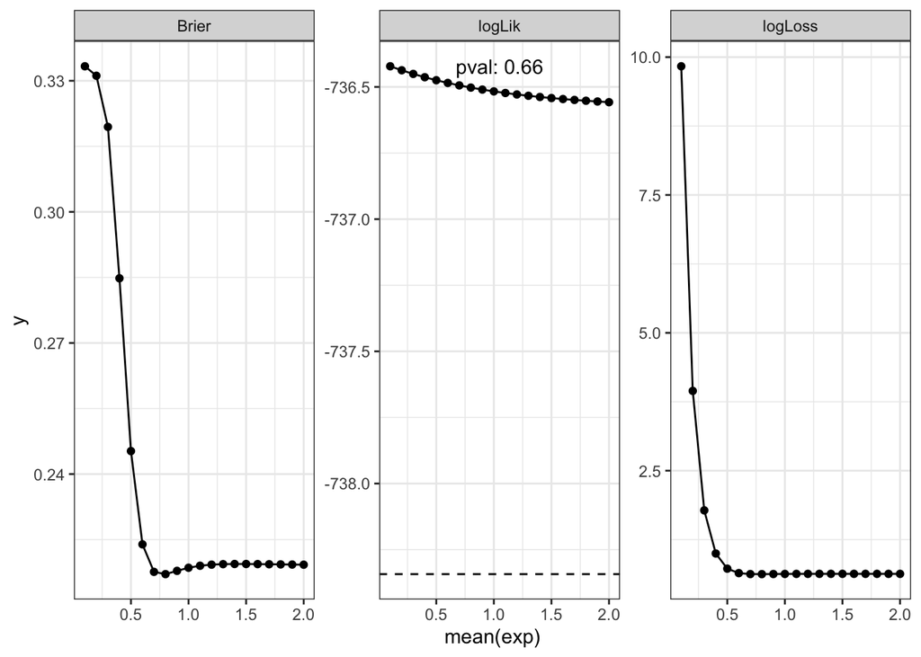

```r
best_fit_twin <- exp_profiling(exp = seq(0.1, 2, 0.1),
                               twin_mod_logit, train_data_twin, test_data_twin)
best_fit_twin$plot
```

```r
est_accuracy(null_mod, test_data_twin, name = "null") |>
  dplyr::bind_rows(best_fit_twin$data) |>
  arrange(Brier)
```

```
## # A tibble: 21 × 5
##    name     logLik logLoss Brier exponent
##    <chr>     <dbl>   <dbl> <dbl>    <dbl>
##  1 Exp: 0.8  -737.   0.624 0.217      0.8
##  2 Exp: 0.7  -736.   0.625 0.218      0.7
##  3 Exp: 0.9  -737.   0.626 0.218      0.9
##  4 Exp: 1    -737.   0.628 0.219      1
##  5 null      -741.   0.629 0.219     NA
##  6 Exp: 1.1  -737.   0.629 0.219      1.1
##  7 Exp: 2    -737.   0.629 0.219      2
##  8 Exp: 1.2  -737.   0.629 0.219      1.2
##  9 Exp: 1.9  -737.   0.629 0.219      1.9
## 10 Exp: 1.8  -737.   0.629 0.219      1.8
## # ℹ 11 more rows
```

Check if changing link fn helps predictive fit.

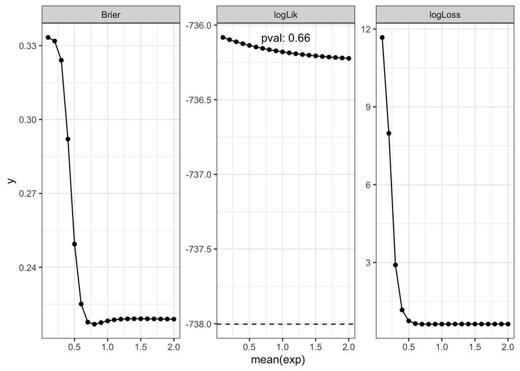

```r
output_table <- best_fit_twin$data |>
  mutate(link = "logit") |>
  bind_rows(probit_fit_twin$data |>
              mutate(link = "probit")) |>
  bind_rows(est_accuracy(null_mod, test_data_twin, name = "null") |>
              mutate(link = "logit")) |>
  ## Arrange nicely
  select(link, exponent, Brier, logLoss, logLik) |>
  dplyr::arrange(Brier)
output_table
```

```
## # A tibble: 41 × 5
##    link   exponent Brier logLoss logLik
##    <chr>     <dbl> <dbl>   <dbl>  <dbl>
##  1 probit      0.8 0.217   0.623  -736.
##  2 logit       0.8 0.217   0.624  -737.
##  3 probit      0.9 0.218   0.625  -736.
##  4 logit       0.7 0.218   0.625  -736.
##  5 probit      0.7 0.218   0.625  -736.
##  6 logit       0.9 0.218   0.626  -737.
##  7 probit      1   0.218   0.627  -736.
##  8 logit       1   0.219   0.628  -737.
##  9 probit      1.1 0.219   0.628  -736.
## 10 probit      1.2 0.219   0.628  -736.
## # ℹ 31 more rows
```

Probit model with 0.8 exponent is best.

```r
##Save output to include in supp material
write.csv(output_table |>
            mutate(across(logLik:Brier, \(x) round(x, 4)),
                   n = 1:n()) |>
            ## Only include top 10
            ## Always include null model as well
            filter(n <= 10 | is.na(exponent)) |>
            select(-n),
          here::here("./data/model_accuracy/twin.csv"), row.names = FALSE)
```

#### Plot

Probit model predicts slightly stronger DD effects.

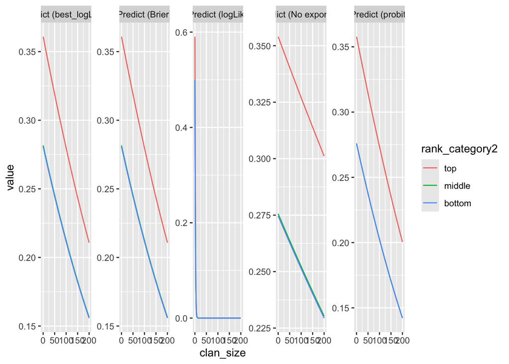

```r
## Best model based on log-likelihood
best_logLik  <- fit_exp(x = best_fit_twin$data$exponent[best_fit_twin$data$logLik == max(best_fit_twin$data$logLik)],
                        model = twin_mod_logit,
                        train_data = train_data_twin, verbose = FALSE)
## Best logit model based on Brier score
best_Brier  <- fit_exp(x = best_fit_twin$data$exponent[best_fit_twin$data$Brier == min(best_fit_twin$data$Brier)],
                       # best_fit_twin$data$exponent[best_fit_twin$data$Brier == min(best_fit_twin$data$Brier)],
                       model = twin_mod_logit,
                       train_data = train_data_twin, verbose = FALSE)
## Best probit model based on Brier score
best_probit <- fit_exp(x = probit_fit_twin$data$exponent[probit_fit_twin$data$Brier == min(probit_fit_twin$data$Brier)],
                       model = probit_mod_twin,
                       train_data = train_data_twin, verbose = FALSE)
## Best model based on log loss function
best_logLoss  <- fit_exp(x = best_fit_twin$data$exponent[best_fit_twin$data$logLoss == min(best_fit_twin$data$logLoss)],
                         model = twin_mod_logit,
                         train_data = train_data_twin, verbose = FALSE)
## Model with no exponent
noexp  <- fit_exp(x = 1,
                  model = twin_mod_logit,
                  train_data = train_data_twin, verbose = FALSE)

plot_data <- expand.grid(start_clan = "A", clan_size = 0:200, after1y_effort_all = 1,
                         rank_category2 = c("top", "middle", "bottom"), age = 120, months = 12) %>%
  mutate(`Predict (logLik)` = as.numeric(predict(best_logLik, newdata = ., type = "response", re.form = NA)),
         `Predict (Brier)` = as.numeric(predict(best_Brier, newdata = ., type = "response", re.form = NA)),
         `Predict (best_logLoss)` = as.numeric(predict(best_logLoss, newdata = ., type = "response", re.form = NA)),
         `Predict (probit)` = as.numeric(predict(best_probit, newdata = ., type = "response", re.form = NA)),
         `Predict (No exponent)` = as.numeric(predict(noexp, newdata = ., type = "response", re.form = NA))) %>%
  tidyr::pivot_longer(starts_with("Pred"))

ggplot(data = plot_data) +
  geom_line(aes(x = clan_size, y = value, colour = rank_category2)) +
  facet_wrap(facets = ~name, scales = "free_y", nrow = 1)
```

### Male dispersal

```r
set.seed(10)
whole_data_disp <- model_data$M_second_disp_data |>
  ## Filter out not full years
  dplyr::filter(year <= end_yr) |>
  dplyr::select(second_disp, age, is_philo, start_clan)

test_sample <- sample(1:nrow(whole_data_disp), size = as.integer(nrow(whole_data_disp)*0.05), replace = FALSE)

train_data_disp <- whole_data_disp[-test_sample, ]
test_data_disp  <- whole_data_disp[test_sample, ] |>
  rename(event = second_disp)
```

```r
null_mod <- spaMM::fitme(second_disp ~ 1,
                         data = train_data_disp,
                         method = "PQL/L", family = binomial(link = "logit"))

disp_mod_logit_poly1 <- spaMM::fitme(second_disp ~ age + is_philo + start_clan,
                               data = train_data_disp,
                               method = "PQL/L", family = binomial(link = "logit"))

disp_mod_logit_poly2 <- spaMM::fitme(second_disp ~ poly(age, 2) + is_philo + start_clan,
                               data = train_data_disp,
                               method = "PQL/L", family = binomial(link = "logit"))
```

Compare different models and null model based on predictive accuracy.

```r
polynome_mods_disp <- list(null_mod, disp_mod_logit_poly1, disp_mod_logit_poly2)
polynome_accuracy_disp <- purrr::map2_dfr(.x = polynome_mods_disp, .y = c("null", "poly1", "poly2"), .f = est_accuracy,
                                          test_data = test_data_disp)
polynome_accuracy_disp |>
  arrange(Brier)
```

```
## # A tibble: 3 × 4
##   name  logLik logLoss   Brier
##   <chr>  <dbl>   <dbl>   <dbl>
## 1 null   -369.  0.0244 0.00364
## 2 poly1  -347.  0.0253 0.00364
## 3 poly2  -346.  0.0253 0.00365
```

Null model (intercept only) seems best. Try also with probit fit.

```r
null_mod_probit <- update(null_mod, family = binomial(link = "probit"))

disp_mod_probit_poly1 <- update(disp_mod_logit_poly1, family = binomial(link = "probit"))

disp_mod_probit_poly2 <- update(disp_mod_logit_poly2, family = binomial(link = "probit"))
```

Compare different models and null model based on predictive accuracy.

```r
polynome_mods_disp_probit <- list(null_mod_probit, disp_mod_probit_poly1, disp_mod_probit_poly2)
polynome_accuracy_disp_probit <- purrr::map2_dfr(.x = polynome_mods_disp, .y = c("null", "poly1", "poly2"), .f = est_accuracy,
                                          test_data = test_data_disp)
polynome_accuracy_disp_probit |>
  arrange(Brier)
```

```
## # A tibble: 3 × 4
##   name  logLik logLoss   Brier
##   <chr>  <dbl>   <dbl>   <dbl>
## 1 null   -369.  0.0244 0.00364
## 2 poly1  -347.  0.0253 0.00364
## 3 poly2  -346.  0.0253 0.00365
```

Same outcome with probit.

```r
output_table <- polynome_accuracy_disp |>
  mutate(link = "logit",
         exponent = c(NA, 1, 2)) |>
  bind_rows(polynome_accuracy_disp_probit |>
              mutate(link = "probit",
         exponent = c(NA, 1, 2))) |>
  ## Arrange nicely
  select(link, exponent, Brier, logLoss, logLik) |>
  dplyr::arrange(Brier)
output_table
```

```
## # A tibble: 6 × 5
##   link   exponent   Brier logLoss logLik
##   <chr>     <dbl>   <dbl>   <dbl>  <dbl>
## 1 logit        NA 0.00364  0.0244  -369.
## 2 probit       NA 0.00364  0.0244  -369.
## 3 logit         1 0.00364  0.0253  -347.
## 4 probit        1 0.00364  0.0253  -347.
## 5 logit         2 0.00365  0.0253  -346.
## 6 probit        2 0.00365  0.0253  -346.
```

```r
##Save output to include in supp material
write.csv(output_table |>
            mutate(across(logLik:Brier, \(x) round(x, 4)),
                   n = 1:n()) |>
            ## Only include top 10
            ## Always include null model as well
            filter(n <= 10 | is.na(exponent)) |>
            select(-n),
          here::here("./data/model_accuracy/disp.csv"), row.names = FALSE)
```

#### Plot

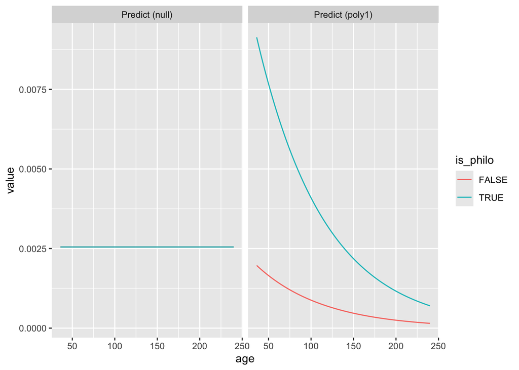

```r
plot_data <- expand.grid(start_clan = "A", is_philo = c(TRUE, FALSE), age = 36:240) %>%
  mutate(`Predict (poly1)` = as.numeric(predict(disp_mod_logit_poly1, newdata = ., type = "response", re.form = NA)),
         `Predict (null)` = as.numeric(predict(null_mod, newdata = ., type = "response", re.form = NA))) %>%
  tidyr::pivot_longer(starts_with("Pred"))

ggplot(data = plot_data) +
  geom_line(aes(x = age, y = value, colour = is_philo)) +
  facet_wrap(facets = ~name, nrow = 1)
```

## Save best models

```r
top_models <- list(
  # F survival: logit, exponent 1, age polynome 2
  allF = fit_exp(x = best_fit_Fsurv$data$exponent[best_fit_Fsurv$data$Brier == min(best_fit_Fsurv$data$Brier)],
                       model = F_surv_mod_logit_poly2,
                       train_data = train_data_Fsurv, verbose = FALSE),
  # M pre-dispersal: probit, exponent 1, age polynome 2
  predispM = fit_exp(x = probit_fit_PreMsurv$data$exponent[probit_fit_PreMsurv$data$Brier == min(probit_fit_PreMsurv$data$Brier)],
                       model = probit_mod_PreMsurv,
                       train_data = train_data_PreMsurv, verbose = FALSE),
  # M post-dispersal: logit, exponent 1.4, age polynome 2
  postdispM = fit_exp(x = best_fit_PostMsurv$data$exponent[best_fit_PostMsurv$data$Brier == min(best_fit_PostMsurv$data$Brier)],
                       model = PostM_surv_mod_logit_poly2,
                       train_data = train_data_PostMsurv, verbose = FALSE),
  # F primi repro: Probit, exponent 1 (atan fn for month)
  primirepro = fit_exp(x = probit_fit_Fprimi$data$exponent[probit_fit_Fprimi$data$Brier == min(probit_fit_Fprimi$data$Brier)],
                       model = probit_mod_Fprimi,
                       train_data = train_data_Fprimi, verbose = FALSE),
  # F non-primi repro: Logit, exponent 1 (atan fn for month)
  nonprimirepro = fit_exp(x = best_fit_Fnonprimi$data$exponent[best_fit_Fnonprimi$data$Brier == min(best_fit_Fnonprimi$data$Brier)],
                       model = F_repro_nonprimi_mod_logit,
                       train_data = train_data_Fnonprimi, verbose = FALSE),
  # Twin: probit, exponent 0.8
  twin = fit_exp(x = probit_fit_twin$data$exponent[probit_fit_twin$data$Brier == min(probit_fit_twin$data$Brier)],
                       model = probit_mod_twin,
                       train_data = train_data_twin, verbose = FALSE),
  disp = spaMM::fitme(second_disp ~ 1,
                         data = train_data_disp,
                         method = "PQL/L", family = binomial(link = "logit"))
  )

saveRDS(top_models, here::here("./data/model_list.RDS"))
```